# L1 - Intro to RStudio

## Introductions

- Instructor: Sotirios Damouras
  - Pronounced [s-aw-t-EE-r-ee-aw-s](https://www.youtube.com/watch?v=rV5hLFZxPls) or Sam
  - Email: sdamouras@utsc.utoronto.ca
  - Webpage: http://www.utsc.utoronto.ca/~sdamouras/
  - Office hours: MO 11-13 / WE 11-13 / FR 13-15 @ IC456
- TA's
  - Xichen (Sherry) He (xichen.he@mail.utoronto.ca)
  - Jiali Pan (jiali.pan@mail.utoronto.ca)
  - Xincheng Zhang (xincheng.zhang@mail.utoronto.ca)

## About the course

- [**Science**](https://en.wikipedia.org/wiki/Science): systematic organization & creation of *knowledge*, in form of *testable* explanations/predictions about the world
- [**Data Science**](https://en.wikipedia.org/wiki/Data_science): field that uses scientific methods to *extract knowledge & insights from data*
  - [*Scientific method*](https://en.wikipedia.org/wiki/Scientific_method) invloves making conjectures and testing them using observation or experimentation.
- In short, this course is about **answering questions using data**.

## About the course

- Unfortunately, cannot answer *every* question using data.
- But certain *types* of questions can be reasonably addressed with data
  - **Estimation**: What % of the population gets the flu?
  - **Inference**: Should I take drug X for the flu?
  - **Prediction**: Will *I* get the flu?

## Data Science in Action

[figure not shown]

## Course Goals

- Be able to conduct a *systematic investigation of a question/problem using data*. In particular:
  - Organize & manipulate data
  - Explore & investigate data graphically
  - Deal with variability & estimation
  - Formulate & test statistical hypotheses
  - Discover patterns in data & use them for prediction
  - Develop strong statistical computing skills
  - Communicate statistical ideas & results effectively

## Resources

- Logistics
  - *All* course material (lecture slides, assignments, grades, communications) available through [Quercus](https://q.utoronto.ca/)
- Textbooks
  - [R for Data Science](http://r4ds.had.co.nz)
  - [Introductory Statistics with Randomization and Simulation](https://www.openintro.org/download.php?file=isrs1_tablet&referrer=/stat/textbook.php)
  - [An Introduction to Statistical Learning](http://www-bcf.usc.edu/~gareth/ISL/)

## Course Evaluation

| Item | Weight | Notes |
| --- | --- | --- |
| Worksheets | 15% | semi-weekly, best 20/23 |
| Project | 20% | progress reports & final presentation |
| Midterm | 25% | computer-based |
| Final | 40% | computer-based |

## Course Project

- Project Topic [**Is university education worth it ?**](https://www.theglobeandmail.com/report-on-business/is-the-university-experience-worth-the-cost/article31703109/)
- Purposefully open-ended question; answer various aspects *using data*
  - Collect and examine relevant data
  - Formulate interesting questions
  - Use data to address them convincingly

## Course Project

- Hope you don't drop out based on your analysis :)

[figure not shown]

## Lecture Goals

- Getting started with R/RStudio
  - Using the RStudio IDE
  - Quick run-through of R
  - Writing *RMarkdown* reports
- Readings
  - Quick guide to [Rmarkdown](https://bookdown.org/yihui/rmarkdown/basics.html#basics)

## RStudio

- Install [R](https://cran.r-project.org/) and [RStudio](https://www.rstudio.com/) for Linux/Windows/Mac
  - Alternatively, use cloud version at [RStudio Cloud](https://rstudio.cloud/)

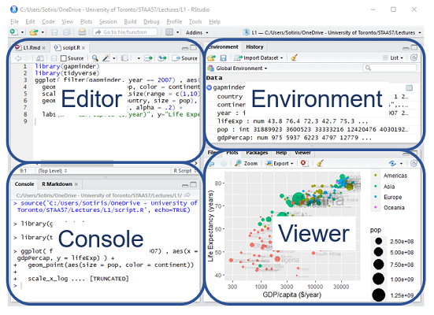

## RStudio Workflow

- Create folder and associated [Rstudio project](https://support.rstudio.com/hc/en-us/articles/200526207-Using-Projects)
  - Container for your data, code, and output files
- Write code (.R/Rmd scripts) in *Editor*
- Run commands/scripts, interact with R in *Console*
- Check available variables/data in *Environment*
- Look at output/documentation/files in *Viewer*

## R Philosophy

- Information is contained in **objects**
  - E.g. data, variables, models, plots
- Operations are performed by **functions**
  - E.g. sorting data, fitting models, plotting results
- Carry out analysis by applying functions to objects

```r
my_numbers = 1:3
sum(my_numbers)
## [1] 6
```

## R packages

- R comes pre-loaded with basic functions; for extra functionality there are two options:
  - Create your own: *R programming*
  - Use someone else's: *R Packages*
- **R Packages** are bundles of reusable functions, data, & documentation
  - Packages must be downloaded *once* w/ `install.packages()`
  - To use a package, you must load it into R session w/ `library()`

```r
install.packages("package_name")
library(package_name)
```

## Getting Help

- Get function documentation using `help()` or `?`
  - See description, arguments, results & examples

```r
help(fun_name)
? help
```

- For help on packages

```r
help( package = "package_name" )
```

## Input/Output

- Read/write tabular data from/to spreadsheet-like file (.csv or comma separated values)

```r
my_data = read.csv( file = "C:/Users/Sotiris/Documents/data.csv")
write.csv( my_data, file = "C:/Users/Sotiris/Documents/data.csv")
```

- Read/write binary representation of *select* R object

```r
save( obj1, obj2, file = "C:/Users/Sotiris/Documents/my_objects.Rdata")
```

- Save *all* objects in `in .RData` file

```r
save.image()
```

## Directories

- Absolute file paths ('C:/Users/Sotiris/…') are **BAD** for reproducibility
- Instead, use **relative** paths with respect to your **working directory**
  - Find/set working directory with `getwd()`/`setwd()`
  - Access working directory directly with

```r
getwd()
my_data = read.csv( file = 'data_folder/data.csv')
```

## R Markdown

- [Rmarkdown](https://rmarkdown.rstudio.com/) is a framework for creating *reproducible* reports
- Rmarkdown scripts combine together:
  - R code for performing data analysis
  - Markdown code for authoring documents
- Actually, these very slides are written in Rmarkdown
- Let's create your first report with Rmarkdown